# IODS course project

## The Golden Standardise

The beginning tend to have heigher weight of group 2 and 3 than the group 1 throughout the study period is known as tracking. The tracking phenomenon can be seen more clearly in a plot of the standardized values of each observation, i.e., the values obtained by subtracting the relevant occasion mean from the original observation and then dividing by the corresponding visit standard deviation.

```r
library(dplyr)
library(tidyr)
# Standardise the variable weight
RATSL <- RATSL %>%
  group_by(Time) %>%
  mutate(stdweight = (weight-mean(weight))/sd(weight)) %>%
  ungroup()

# Glimpse the data
glimpse(RATSL)
```

```
## Rows: 176
## Columns: 6
## $ ID        <fct> 1, 2, 3, 4, 5, 6, 7, 8, 9, 10, 11, 12, 13, 14, 15, 16, 1, 2,…
## $ Group     <fct> 1, 1, 1, 1, 1, 1, 1, 1, 2, 2, 2, 2, 3, 3, 3, 3, 1, 1, 1, 1, …
## $ WD        <chr> "WD1", "WD1", "WD1", "WD1", "WD1", "WD1", "WD1", "WD1", "WD1…
## $ weight    <int> 240, 225, 245, 260, 255, 260, 275, 245, 410, 405, 445, 555, …
## $ Time      <int> 1, 1, 1, 1, 1, 1, 1, 1, 1, 1, 1, 1, 1, 1, 1, 1, 8, 8, 8, 8, …
## $ stdweight <dbl> -1.0011429, -1.1203857, -0.9613953, -0.8421525, -0.8819001, …
```

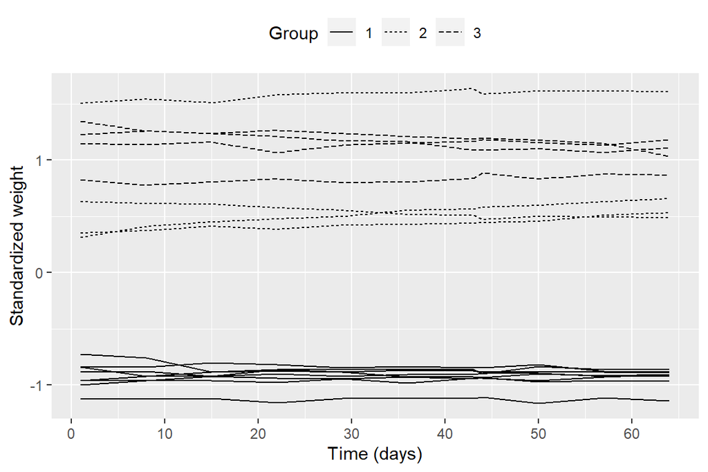

```r
# Plot again with the standardised weight
library(ggplot2)
ggplot(data = RATSL, aes(x = Time, y = stdweight, group = ID))+
  geom_line(aes(linetype = Group))+
  scale_x_continuous(name = "Time (days)", breaks = seq(0, 60, 10))+
  scale_y_continuous(name = "Standardized weight")+
  theme(legend.position = "top")
```

$$se = \frac{sd(x)}{\sqrt{n}}$$

```
## Rows: 33
## Columns: 3
## $ Group <fct> 1, 1, 1, 1, 1, 1, 1, 1, 1, 1, 1, 2, 2, 2, 2, 2, 2, 2, 2, 2, 2, 2…
## $ Time  <int> 1, 8, 15, 22, 29, 36, 43, 44, 50, 57, 64, 1, 8, 15, 22, 29, 36, …
## $ mean  <dbl> 250.625, 255.000, 254.375, 261.875, 264.625, 265.000, 267.375, 2…
```

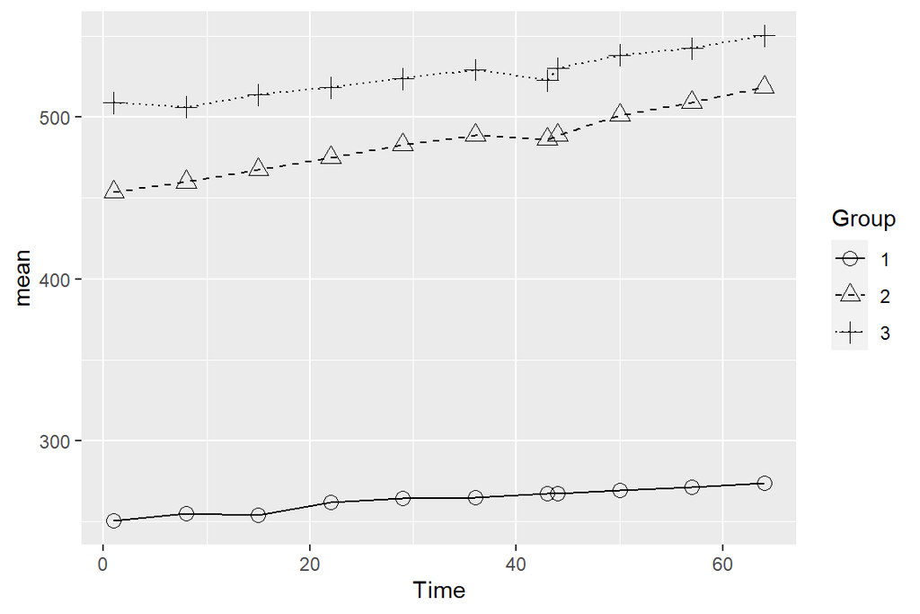

[figure not shown]

In this RAT data set number of samples in each group is unequal, therefore I did not calculated standard error. Here I plotted only the line graph for mean weight. This graph also showing that the group 1 rat has the lowest mean values and there is a large difference than the mean values of group 2 and 3. The mean value of group 2 and 3 also differ from each other.

## t-test and Anova of RATS data

The informal graphical material presented up to now has all indicated the difference in the three rat groups. In this data set we have 3 levels group but for doing t-test, we need 2 levels of group with exactly same length. Therefor, I think here through t-test we can only check whether the mean difference of group 1 is significantly different from group 2 & 3 or not by t-test seperately between group 1 and group 2 and group 1 and group 3.

```r
t.test(mean ~ Group, data = RATSS[1:22,], var.equal = TRUE)
```

```
##
##  Two Sample t-test
##
## data:  mean by Group
## t = -34.302, df = 20, p-value < 2.2e-16
## alternative hypothesis: true difference in means between group 1 and group 2 is not equal to 0
## 95 percent confidence interval:
##  -234.4275 -207.5498
## sample estimates:
## mean in group 1 mean in group 2
##        263.7159        484.7045
```

```r
t.test(mean ~ Group, data = RATSS[c(1:11,23:33),], var.equal = TRUE)
```

```
##
##  Two Sample t-test
##
## data:  mean by Group
## t = -54.855, df = 20, p-value < 2.2e-16
## alternative hypothesis: true difference in means between group 1 and group 3 is not equal to 0
## 95 percent confidence interval:
##  -272.0457 -252.1134
## sample estimates:
## mean in group 1 mean in group 3
##        263.7159        525.7955
```

```r
fit <- lm (mean ~ Group+Time, data = RATSS)
anova(fit)
```

```
## Analysis of Variance Table
##
## Response: mean
##           Df Sum Sq Mean Sq F value    Pr(>F)
## Group      2 437104  218552 5986.85 < 2.2e-16 ***
## Time       1   5457    5457  149.48 5.748e-13 ***
## Residuals 29   1059      37
## ---
## Signif. codes:  0 '***' 0.001 '**' 0.01 '*' 0.05 '.' 0.1 ' ' 1
```